# Determining predictors of domestic violence using logistic regression analysis

## Research question and hypotheses

In this assignment, I am going to study if gender, age, education, non-domestic violent victimization and crime in one’s neighbourhood predict domestic violence victimization. Based on both intuition and some criminological theories that I am not going to focus on here, the following hypotheses are made:

*H1 Women are more likely to have experienced domestic violence than men.*

*H2 Young people are more likely to have experienced domestic violence than the old.*

*H3 Less educated people are more likely to have experienced domestic violence.*

*H4 Those who ha experienced other than domestic violence are more likely to have experienced domestic violence as well.*

*H5 Serious crime problem in one’s neighbourhood increases the risk of having experienced domestic violence.*

## Data

### Public Safety Survey 2009

The data used in this assignment is Public Safety Survey 2009 which is collected by Finnish Police Departments. It is available for research, study and teaching purposes on Yhteiskuntatieteellinen tietoarkisto and can be downloaded [here](https://services.fsd.uta.fi/catalogue/FSD2502).

The data contains information about Finnish opinion and experiences on policing, public safety and security, victimization, and services in the neighbourhood, and with 46139 cases it is a nationally representative sample of Finnish population aged 15–74.

In the survey questionnaire, information about domestic violence victimization has been asked as following:

*Have you personally experienced any of the following crimes in the past three years? Where did this happen: Domestic violence*

### Analysis data

In this assignment, a subset of the Public Safety Survey data is used. The r-code for creating the analysis data can be found [here](https://github.com/maijutanskanen/finalassignment/blob/master/wrangling.R)

As only variables used is the analysis were included and cases with missing answers were deleted, there are 6 variables and 40641 cases in the analysis data.

**Dependent variable**

The variable indicating domestic violence victimization during the past three years is coded into a dichotomous one in order to use it as a dependent variable in logistic regression analysis.

```r
summary(safety$domestic)
```

```
##    no   yes
## 39873   768
```

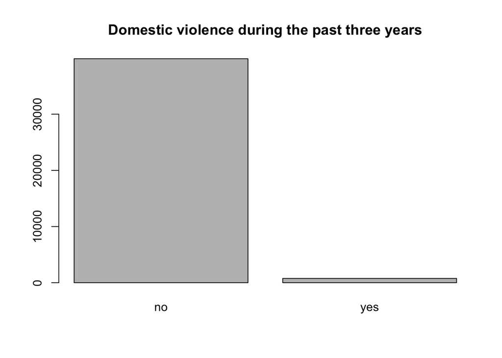

```r
counts <- table(safety$domestic)
barplot(counts, main = "Domestic violence during the past three years")
```

**Independent variables**

Gender, age in years, education level, non-domestic violent victimization during the past three years and crime problem in respondent’s neighbourhood are used as independent variables.

Education is coded into three groups: primary or less, secondary and tertiary. Non-domestic violent victimization is coded into a dichotomous variable.

Crime problem in respondent’s neighbourhood is measured as serious or not serious based on the questionnaire’s question How serious a problem you consider crime to be in or around your neighbourhood? ‘Can’t say’ answers were coded as missing.

The summaries and distributions of the independent variables are displayed below.

The mean age of the respondents is 49 years, and there are more women than men in the data. Secondary education is the most common education level.

A bit more respondents had experienced non-domestic violence compared to domestic violence: 1315 (3,2 %). 7361 (18,1 %) respondents considered crime problem in their neighbourhood serious.

```r
summary (safety[-4])
```

```
##     gender          education           crimeprob     violence
##  Female:21859   Primary  :12040   Not serious:33280   no :39326
##  Male  :18782   Secondary:18548   Serious    : 7361   yes: 1315
##                 Tertiary :10053
##
##
##
##       age
##  Min.   :15.00
##  1st Qu.:37.00
##  Median :52.00
##  Mean   :49.07
##  3rd Qu.:62.00
##  Max.   :75.00
```

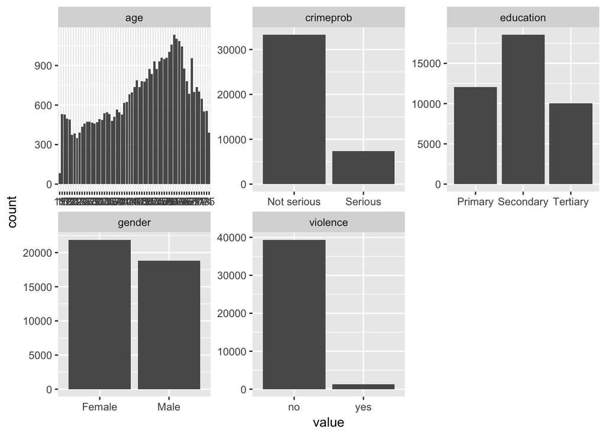

```r
gather(safety[-4]) %>% ggplot(aes(value)) + facet_wrap("key", scales = "free") + geom_bar()
```

**Relationships between variables**

Before the actual analysis, relationships between the variables are studied using simple descriptive methods.

The cross-tabulation below shows that more women had experienced domestic violence compared to men (2,8 % vs. 0,9 %).

```r
table1 <-  table(safety$gender, safety$domestic)
prop.table(table1, 1)
```

```
##
##                   no         yes
##   Female 0.972368361 0.027631639
##   Male   0.991268236 0.008731764
```

Surprisingly, there are no big differences in prevalence of domestic violence between education groups even though those with secondary education had experienced slightly more domestic violence than those with lower or higher educational level.

```r
table2 <-  table(safety$education, safety$domestic)
prop.table(table2, 1)
```

```
##
##                     no        yes
##   Primary   0.98197674 0.01802326
##   Secondary 0.97972827 0.02027173
##   Tertiary  0.98259226 0.01740774
```

Those who had experienced non-domestic violence had experienced more domestic violence (19,2 % vs. 1,3 %).

```r
table3 <-  table(safety$violence, safety$domestic)
prop.table(table3, 1)
```

```
##
##               no        yes
##   no  0.98687891 0.01312109
##   yes 0.80836502 0.19163498
```

Those who considered crime problem in their neighbourhood serious reported more than twice as much domestic violence than those with considered problem not serious.

```r
table4 <-  table(safety$crimeprob, safety$domestic)
prop.table(table4, 1)
```

```
##
##                       no        yes
##   Not serious 0.98431490 0.01568510
##   Serious     0.96658063 0.03341937
```

Based on the boxplot below, it seems like young people had experienced more domestic violence in both genders.

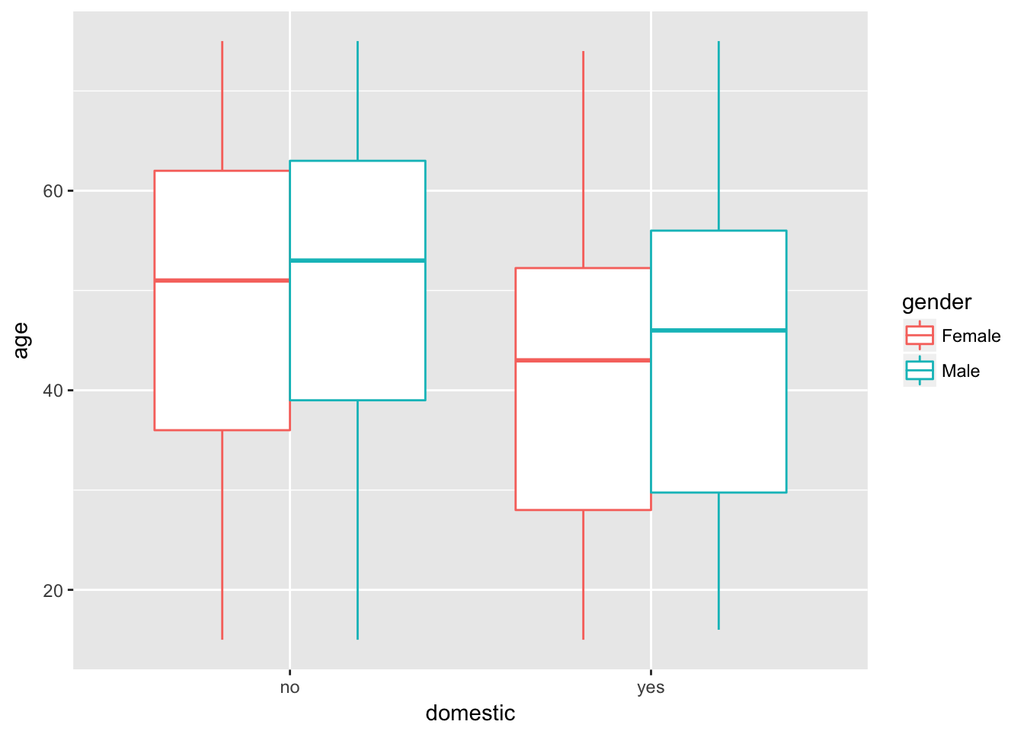

```r
g1 <- ggplot(safety, aes(x = domestic, y = age))
g1 + geom_boxplot(aes(col = gender))
```

## Analysis

### Method

Logistic regression analysis is a method used to predict binary outcomes. It can be conducted using multiple explanatory variables that can be either categorical or continuous. Results of logistic regression analysis are usually represented as odds ratios for each predictor; they can be interpreted as associations between a predictor and an outcome variable.

### Logistic regression analysis

Before the analysis, reference categories of “gender” and “education” are changed. Then, a logistic regression model is built using domestic violence as the outcome variable and the rest of the variables as predictors. The results of the analysis are seen below. All the independent variables except education are statistically significant predictors (p<0.001); at this point, hypothesis H3 can be rejected.

```r
safety$gender <- relevel(safety$gender, ref = "Male")
safety$education <- relevel(safety$education, ref = "Tertiary")
m <- glm(domestic ~  gender + violence + age + education + crimeprob, data = safety, family = "binomial")
summary(m)
```

```
##
## Call:
## glm(formula = domestic ~ gender + violence + age + education +
##     crimeprob, family = "binomial", data = safety)
##
## Deviance Residuals:
##     Min       1Q   Median       3Q      Max
## -1.1439  -0.1987  -0.1609  -0.0947   3.4125
##
## Coefficients:
##                     Estimate Std. Error z value Pr(>|z|)
## (Intercept)        -4.688918   0.154784 -30.293  < 2e-16 ***
## genderFemale        1.365173   0.093123  14.660  < 2e-16 ***
## violenceyes         2.876742   0.090388  31.827  < 2e-16 ***
## age                -0.015489   0.002364  -6.551 5.71e-11 ***
## educationPrimary    0.082370   0.107108   0.769    0.442
## educationSecondary  0.012857   0.096198   0.134    0.894
## crimeprobSerious    0.533147   0.083140   6.413 1.43e-10 ***
## ---
## Signif. codes:  0 '***' 0.001 '**' 0.01 '*' 0.05 '.' 0.1 ' ' 1
##
## (Dispersion parameter for binomial family taken to be 1)
##
##     Null deviance: 7617.4  on 40640  degrees of freedom
## Residual deviance: 6426.0  on 40634  degrees of freedom
## AIC: 6440
##
## Number of Fisher Scoring iterations: 7
```

Next, the odds ratios and the confidence intervals for them are counted and printed out in order to interpret the results. Following statements can be made:

Women are almost four times more likely to have experienced domestic violence than men. Young people are more likely to have experienced domestic violence than the old. Those who have experienced other than domestic violence are almost 18 times more likely to have experienced domestic violence as well. Serious crime problem in one’s neighbourhood increases the risk of having experienced domestic violence by 1,7.

Thus, hypotheses H1, H2, H4 and H5 can be verified.

```r
OR <- coef(m) %>% exp
CI <- confint(m) %>% exp
cbind(OR, CI)
```

```
##                              OR        2.5 %      97.5 %
## (Intercept)         0.009196631  0.006767533  0.01241665
## genderFemale        3.916401532  3.271739193  4.71433525
## violenceyes        17.756334862 14.862081625 21.18445950
## age                 0.984629955  0.980081441  0.98920999
## educationPrimary    1.085857843  0.880613205  1.34048574
## educationSecondary  1.012939731  0.840205694  1.22535807
## crimeprobSerious    1.704287644  1.445895434  2.00326140
```

## Testing the model

Even though the results of the analysis are for most parts as expected, it does not necessarily mean that the model is actually a good one in predicting the outcome variable. That is why it is important to test the predictive power of the model.

In order to do so, two variables are counted based on the regression model: “probability”, indicating the probability of domestic violence victimization being reported according to the model, and “prediction” indicating that according to the model there is more than a 50 % chance of domestic violence victimization being reported.

### Real values vs. predicted values

The actual values of the domestic violence variable and its values predicted by the model are cross-tabulated below. The cross-tabulation shows that based on the model, none of the cases is has more than a 50 % chance of domestic violence victimization being reported; in other words, all the respondents are predicted not to have experienced domestic violence even though there are 768 people who actually reported having been victimized.

```r
probabilities <- predict(m, type = "response")
safety <- mutate(safety, probability = probabilities)
safety <- mutate(safety, prediction = (probability > 0.5))
table(domestic = safety$domestic, prediction = safety$prediction)
```

```
##         prediction
## domestic FALSE
##      no  39873
##      yes   768
```

### Classification error

Next, error produced by the model is studied using loss function and cross-validation. Obviously, both of them result in error of 1,9 %, which is equal to the prevalence of domestic violence in the data. Even though the error is small, it basically means that the model is just as good in predicting domestic violence as simply guessing that nobody has experienced it. In order to have some explanatory power, the error of the model should definitely be smaller than the prevalence of the predicted phenomenon in the data!

```r
loss_func <- function(class, prob) {
  n_wrong <- abs(class - prob) > 0.5
  mean(n_wrong)
}

safety$domestic <- as.numeric(safety$domestic) -1
loss_func(class = safety$domestic, prob = safety$probability)
```

```
## [1] 0.01889717
```

```r
library(boot)
cv <- cv.glm(data = safety, cost = loss_func, glmfit = m, K = 10)

cv$delta[1]
```

```
## [1] 0.01892178
```

## Conclusions

Finally, some conclusions should be made based on what have been done.

Firstly, there are statistically significant predictors of domestic violence victimization based on the analysis. Interestingly, out of the explanatory variables used in the analysis, non-domestic violent victimization is the strongest predictor. It has a greater association with domestic violence victimization than gender.

Secondly, testing the model shows that it actually is not good in predicting domestic violence victimization. This is basically caused by the very low proportion of respondents who had experienced domestic violence; in order to successfully predict a rare phenomenon like this, the model should be very strong.

Yet, as a sociology student, I do still find the results of the analysis interesting: they do reveal associations between phenomena. In my opinion, this is almost as important as successfully predicting things.